# Question

# Solution

1. Interval where $f$ is positive = (-8, -4)
2. Interval where $f$ is negative = (-4, 4)
3. Interval where $f$ is increasing = (-2, 4)
4. Interval where $f$ is decreasing = (-8, -2)
5. Domain = (-8, 4)
6. Range = [-3, 6)

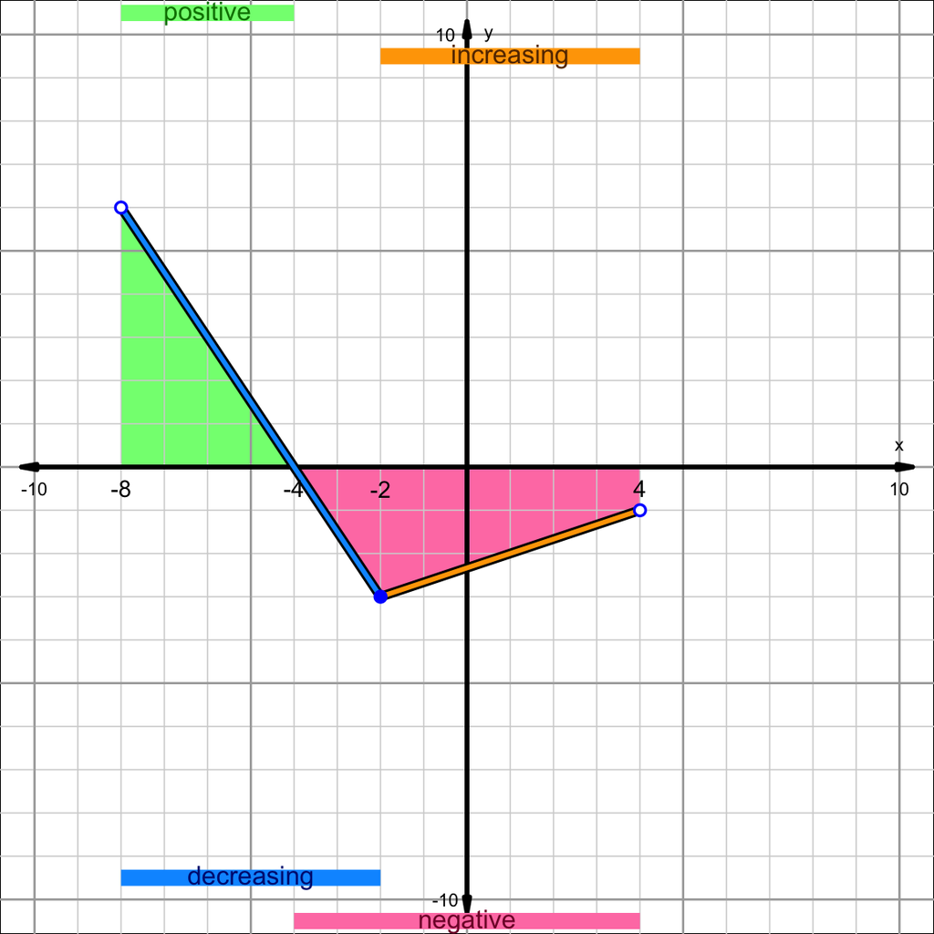

# Meta-information

extype: cloze exclozetype: schoice|schoice|schoice|schoice|schoice|schoice|schoice|schoice|schoice|schoice|schoice|schoice exsolution: 0100000000000000000|0000010000000000000|0000010000000000000|0000000000000100000|0000000100000000000|0000000000000100000|0100000000000000000|0000000100000000000|0100000000000000000|0000000000000100000|0000001000000000000|0000000000000001000 exname: intervals_check